# Laboratorio 9-MD

Leislie R. Manjarrez O.

2023-02-22

Laboratorio 9- T1_03_ESPACIO PRODUCTO(2) - RELACIONAMIENTO “CASO REAL”: EXPORTACIONES HIDALGUENSES

Objetivo: Estimar el relacionamiento (relatedness, proximidad, metrica de distancia entre productos) En este ejercicio vamos a: 1. Cargar nuestra matriz de datos 2. Calcular co ocurrencias entre lugares y productos 3. Estimar el relacionamiento, teniendo como input las co-ocurrencias 4. Graficar 5. Exportar los resultados para trabajarlos con cytoscape o gephi

Primero llamar la libreria de EconGeo

```r
library (EconGeo)
```

```
##  Balland, P.A. (2017) Economic Geography in R: Introduction to the EconGeo Package, Papers in Evolutionary Economic Geography, 17 (09): 1-75
```

Seleccionar el archivo desde la ruta del ordenador, utilizando el panel Data y el icono Import Dataset. Considerar el archivo como From Text (base). Seleccionar en Heading la opcion Yes en la pantalla que aparece y dar clic en Importar. Copiar la ruta que aparece en la consola una vez cargados los datos y pegar en read.csv (“RUTA”). Al correr el comando aparece la matriz en el panel Data

```r
M = as.matrix(
  read.csv("rca_2014.csv" ,
           sep = ",",
           header = T,
           row.names = 1))
```

Para visualizar los primeros 10 datos de la matriz y que es una matriz de 83X429

```r
head (M[,1:10])
```

```
##                         X102 X210 X401 X403 X406 X510 X602 X603 X702 X703
## Acatlán                    0    0    0    0    0    0    0    0    1    0
## Acaxochitlán               0    0    0    0    0    0    0    0    1    0
## Actopan                    0    0    0    0    0    0    0    0    1    0
## Agua Blanca De Iturbide    0    0    0    0    0    0    0    0    1    0
## Ajacuba                    0    0    0    0    0    0    1    0    0    0
## Alfajayucan                0    0    0    0    0    0    0    0    0    0
```

```r
dim (M)
```

```
## [1]  83 429
```

Ejecuta la co-ocurrencias en en este caso de los municipios (lugares)

```r
co.occurrence (M)
```

[output not shown]

[output cut: 2885 more lines]

[output not shown]

Para sacar la co-ocurrencia entre productos t debe ser transpuesta y crear un objeto denominado c

```r
c = co.occurrence (t(M))
```

Estima el relacionamiento o proximidad pero normalizado, para asegurar que el numero de co ocurrencias que observamos. Es mayor al numero de co ocurrencias probables (probailidad condicional)

```r
r = relatedness(c)
```

Teniendo el numero de co-ocurrencia hay que transformar a matriz binaria con el comando siguiente

```r
r[r<1] = 0
r[r>1] = 1
```

Graficar en un primer momento aunque sera muy sucia

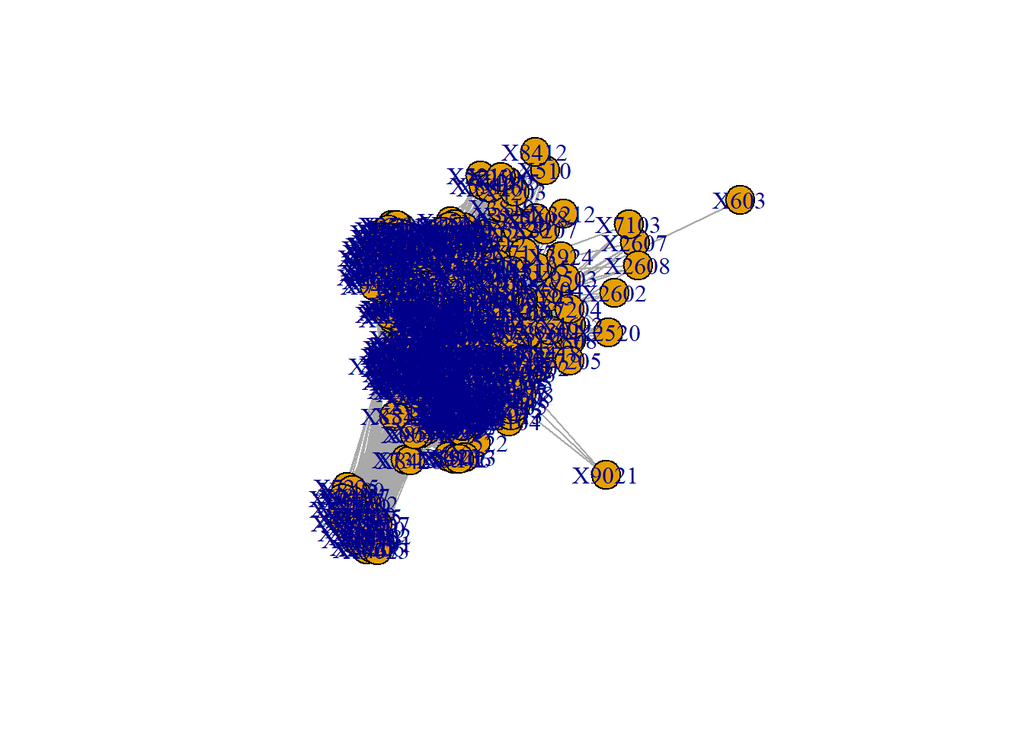

```r
library (igraph)
g1 = graph_from_adjacency_matrix(r, mode = "undirected")
plot(g1)
```

```r
write.csv (r, file="relatedness.csv")
write.csv (c, file="cocurrences.csv")
```